# Time Series Analysis 3

```r
library(forecast)
library(fpp2)
getwd()
```

```
## [1] "C:/Users/Sinan/Desktop"
```

```r
setwd("C:/Users/Sinan/Desktop")
res<-read.csv("UKPlasticPrices.csv",header = TRUE)
x<-ts(res$Price.Index,freq=12,start=1996)
```

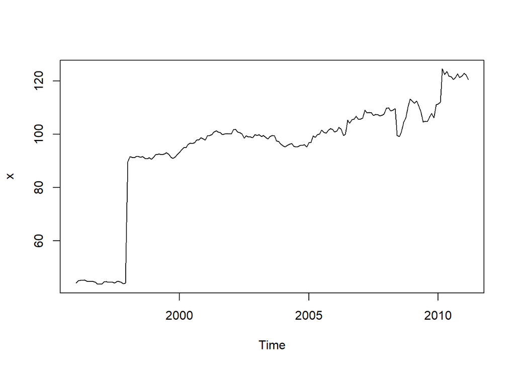

```r
plot(x)
```

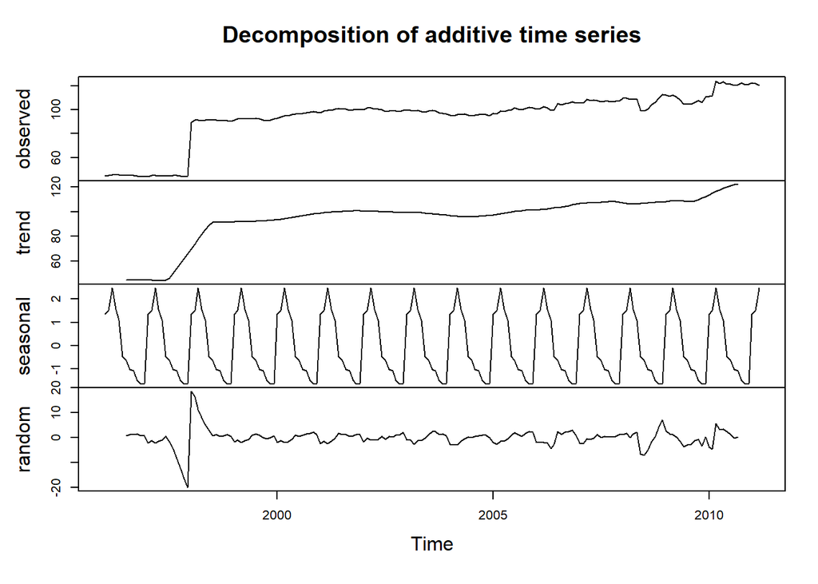

```r
plot(decompose(x))
```

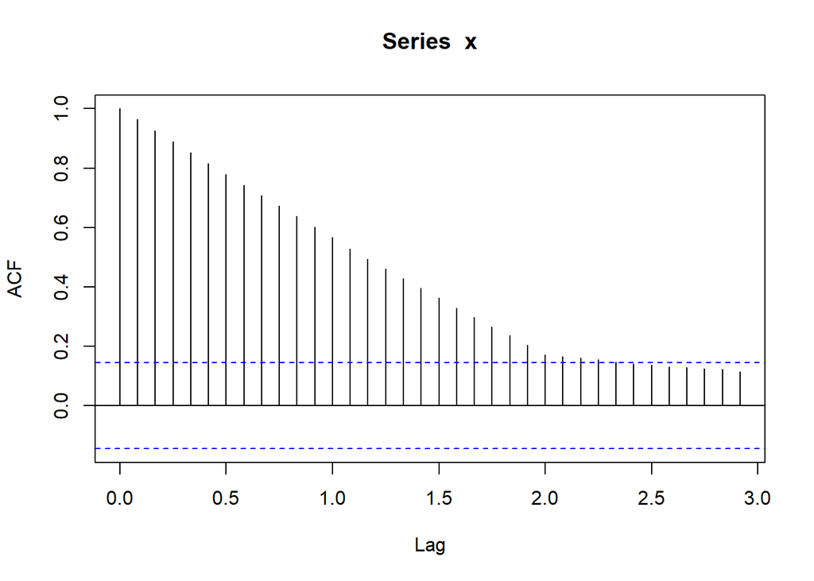

```r
acf(x,lag.max = 35)
```

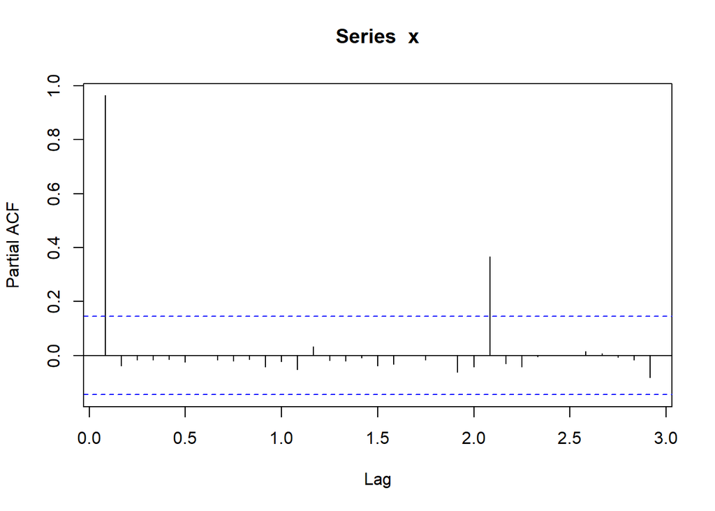

```r
pacf(x,lag.max = 35)
```

#### From the ACF plot it can easily seen that the data has a trend so we should take one level differencing to drop the trend.

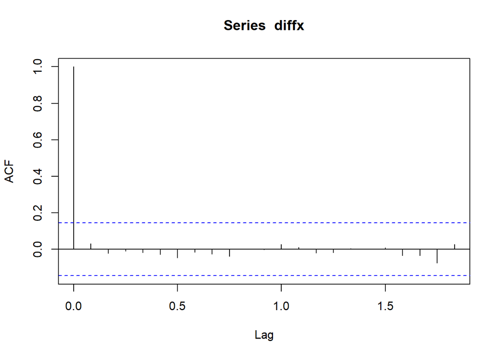

```r
diffx<-diff(x)
acf(diffx)
```

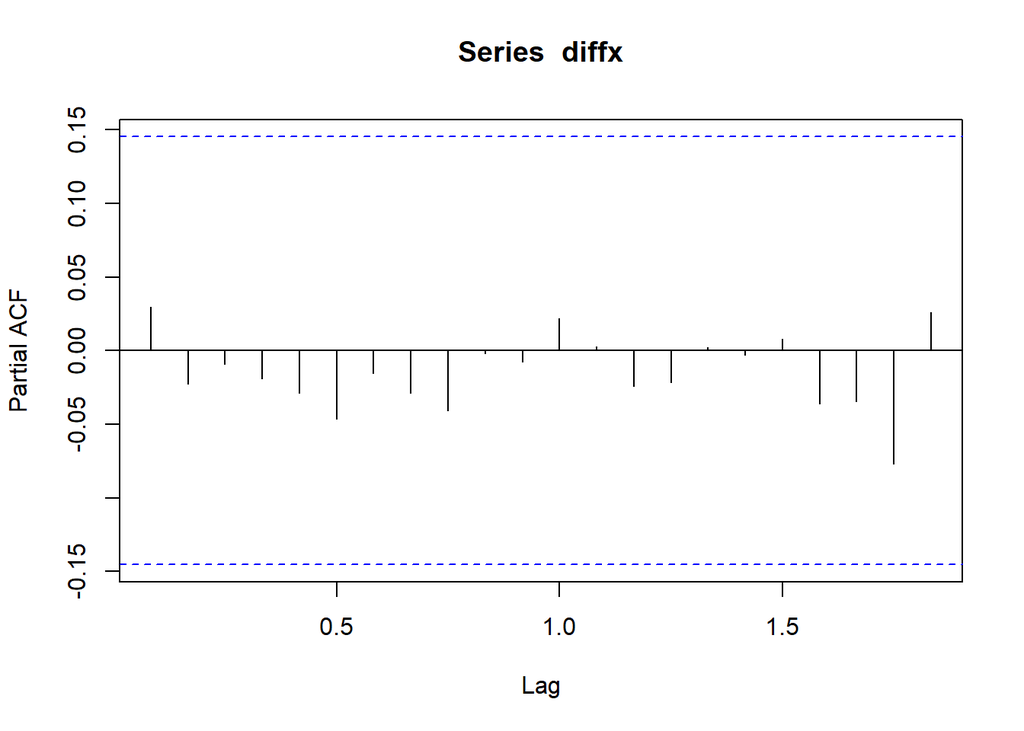

```r
pacf(diffx)
```

#### When we look at the ACF and PACF plots of the differenced data we can see that the trend disappeared.Also,the plots show that there is no dependency between lags so, using AR(0) and MA(0) will be useful for our Arima model.

```r
Arimax<-Arima(x,order = c(0,1,0),include.drift = TRUE)
Arimax
```

```
## Series: x
## ARIMA(0,1,0) with drift
##
## Coefficients:
##        drift
##       0.4192
## s.e.  0.2758
##
## sigma^2 estimated as 13.92:  log likelihood=-497.35
## AIC=998.7   AICc=998.77   BIC=1005.11
```

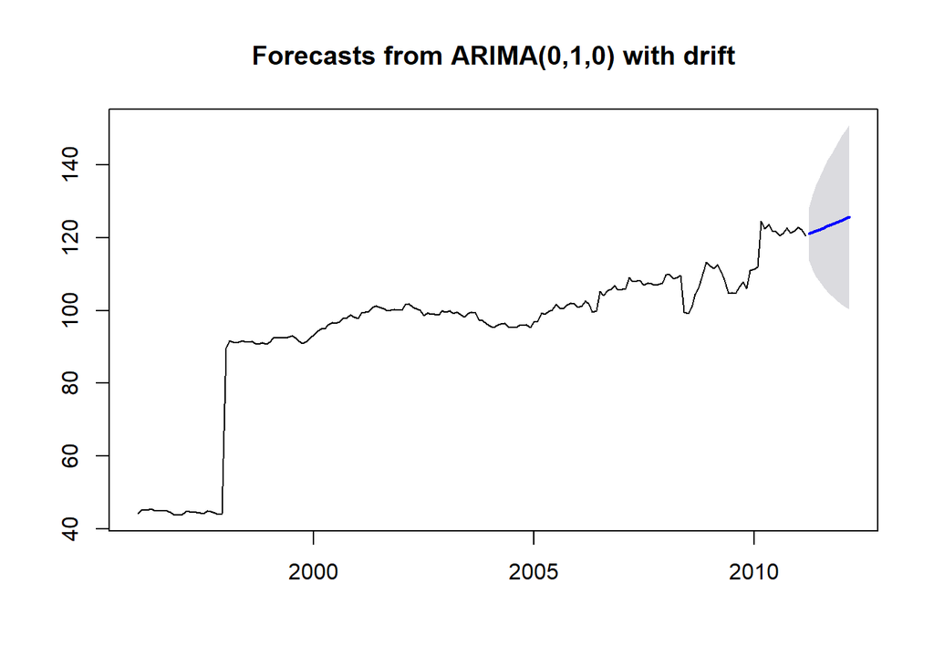

```r
forecast12<-forecast(Arimax,level = c (95),h=12)
plot(forecast12)
```

```r
forecast12
```

```
##          Point Forecast    Lo 95    Hi 95
## Apr 2011       121.0192 113.7078 128.3306
## May 2011       121.4385 111.0986 131.7784
## Jun 2011       121.8577 109.1940 134.5214
## Jul 2011       122.2769 107.6541 136.8997
## Aug 2011       122.6962 106.3474 139.0450
## Sep 2011       123.1154 105.2062 141.0246
## Oct 2011       123.5346 104.1905 142.8788
## Nov 2011       123.9538 103.2741 144.6336
## Dec 2011       124.3731 102.4389 146.3073
## Jan 2012       124.7923 101.6716 147.9130
## Feb 2012       125.2115 100.9623 149.4607
## Mar 2012       125.6308 100.3033 150.9582
```

#### When we look at the data it is seen that the extreme event in the time series data occur in the 24th month,so we omit the data until that point.

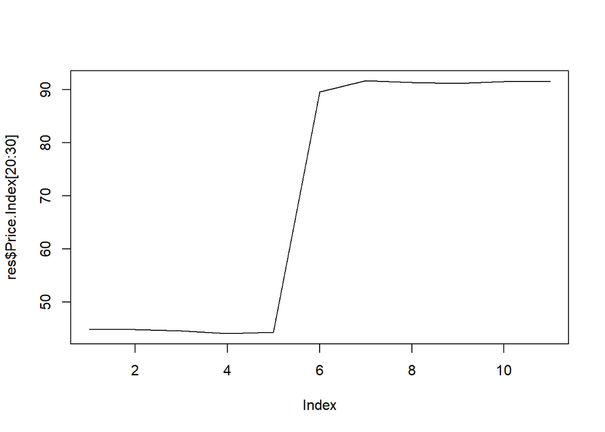

```r
plot(res$Price.Index[20:30],type="l")
```

```r
newres<-res$Month[25:183]
newres<-data.frame(newres)
newres$Price.Index<-res$Price.Index[25:183]

newx<-ts(newres$Price.Index,start = 1998,freq=12)
```

```r
newx
```

```
##        Jan   Feb   Mar   Apr   May   Jun   Jul   Aug   Sep   Oct   Nov
## 1998  89.6  91.7  91.4  91.2  91.6  91.6  91.4  91.6  90.9  90.8  91.2
## 1999  91.4  92.4  92.5  92.5  92.4  92.7  93.1  92.5  91.5  90.9  91.5
## 2000  93.2  94.3  94.9  94.9  96.1  96.7  96.5  96.9  97.9  98.0  98.7
## 2001  97.9  99.4  99.6  99.8 100.8 101.3 100.9 100.5  99.9 100.1 100.3
## 2002 100.2 101.7 101.8 100.8 100.5 100.1  98.6  99.4  99.0  99.0  98.7
## 2003  99.6  99.9  99.2  99.5  98.9  98.2  99.2  99.6  99.4  97.5  97.3
## 2004  95.7  95.3  95.9  96.3  96.5  95.6  95.3  95.4  95.9  95.9  96.1
## 2005  96.9  96.8  99.4  98.9  99.8 100.2 101.6 100.7 100.4 101.4 102.1
## 2006 100.9 101.3 102.6 101.9  99.5 100.0 105.3 104.1 105.5 105.8 106.8
## 2007 105.8 106.0 109.1 108.0 108.2 108.1 107.0 107.5 107.3 106.9 107.2
## 2008 109.8 109.9 108.7 109.1 109.6  99.5  99.2 100.9 104.5 106.3 110.1
## 2009 112.3 111.6 112.5 110.8 108.5 104.6 104.9 104.7 106.6 107.8 106.1
## 2010 111.4 112.0 124.5 122.4 123.5 121.9 121.6 120.5 121.2 122.7 121.3
## 2011 122.8 122.3 120.6
##        Dec
## 1998  90.7
## 1999  92.4
## 2000  98.2
## 2001 100.2
## 2002  99.9
## 2003  96.4
## 2004  95.3
## 2005 101.9
## 2006 105.6
## 2007 107.6
## 2008 113.2
## 2009 111.0
## 2010 121.8
## 2011
```

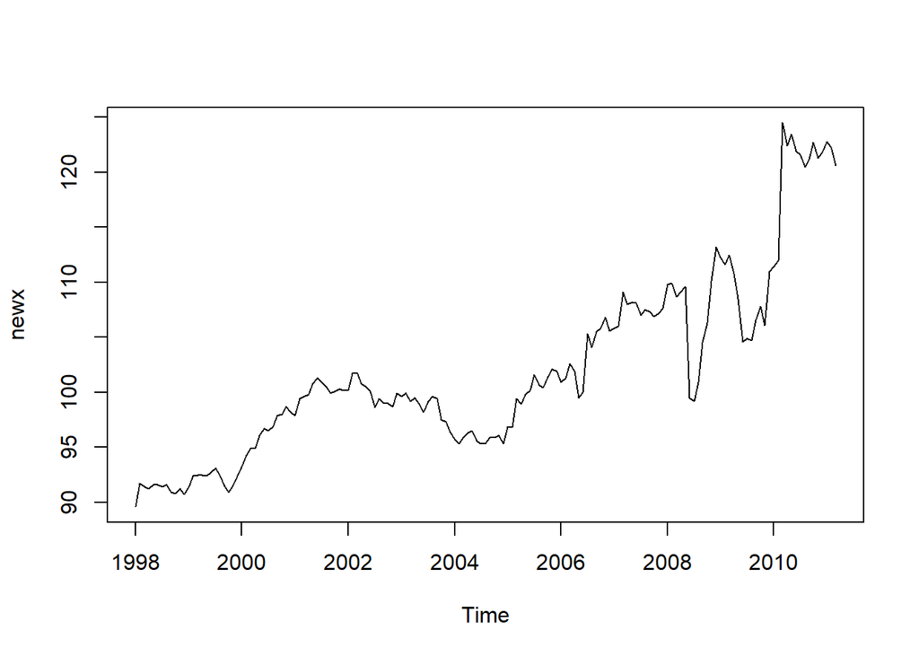

```r
plot(newx)
```

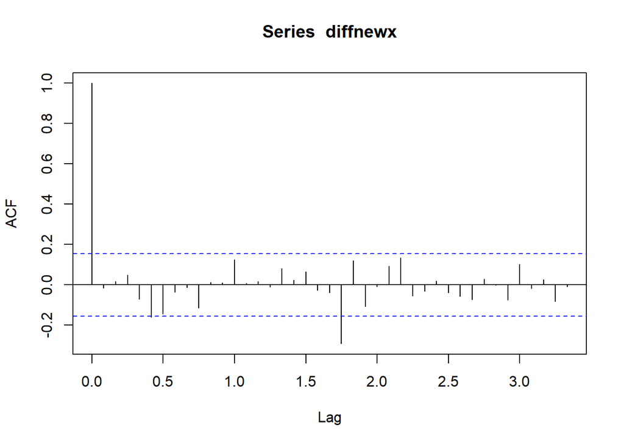

```r
diffnewx<-diff(newx)
acf(diffnewx,lag.max = 40)
```

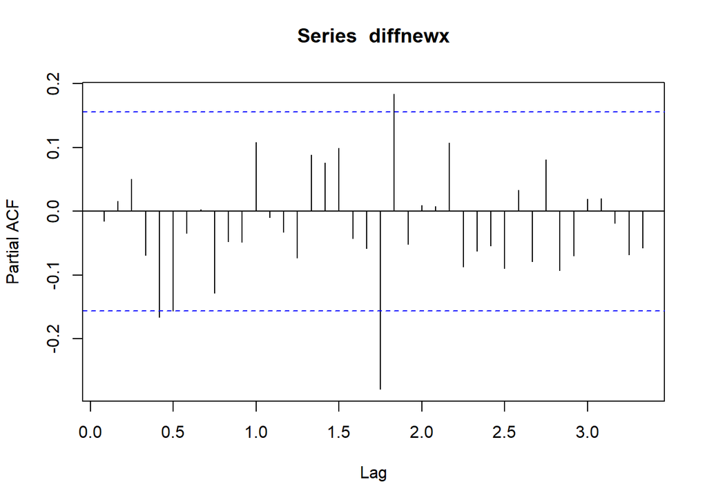

```r
pacf(diffnewx,lag.max = 40)
```

#### To use SAR(1) or SMA(1) is not understood by just looking these plots.In this situation to look at the AIC values of the 2 models will be much comprehensible.

```r
Arimanewx<-Arima(newx,order=c(0,1,0),seasonal = c(0,0,0),include.drift = TRUE)
ArimanewxwithAR<-Arima(newx,order=c(0,1,0),seasonal = c(1,0,0))
ArimanewxwithARdrift<-Arima(newx,order=c(0,1,0),seasonal = c(1,0,0),include.drift = TRUE)
ArimanewxwithMAdrift<-Arima(newx,order=c(0,1,0),seasonal = c(0,0,1),include.drift = TRUE)
ArimanewxwithMA<-Arima(newx,order=c(0,1,0),seasonal = c(0,0,1))
```

```r
Arimanewx
```

```
## Series: newx
## ARIMA(0,1,0) with drift
##
## Coefficients:
##        drift
##       0.1962
## s.e.  0.1400
##
## sigma^2 estimated as 3.115:  log likelihood=-313.46
## AIC=630.92   AICc=631   BIC=637.04
```

```r
ArimanewxwithAR
```

```
## Series: newx
## ARIMA(0,1,0)(1,0,0)[12]
##
## Coefficients:
##         sar1
##       0.1349
## s.e.  0.0776
##
## sigma^2 estimated as 3.091:  log likelihood=-312.95
## AIC=629.89   AICc=629.97   BIC=636.02
```

```r
ArimanewxwithARdrift
```

```
## Series: newx
## ARIMA(0,1,0)(1,0,0)[12] with drift
##
## Coefficients:
##         sar1   drift
##       0.1233  0.1903
## s.e.  0.0780  0.1567
##
## sigma^2 estimated as 3.083:  log likelihood=-312.22
## AIC=630.45   AICc=630.6   BIC=639.63
```

```r
ArimanewxwithMAdrift
```

```
## Series: newx
## ARIMA(0,1,0)(0,0,1)[12] with drift
##
## Coefficients:
##         sma1   drift
##       0.1362  0.1895
## s.e.  0.0851  0.1562
##
## sigma^2 estimated as 3.079:  log likelihood=-312.13
## AIC=630.26   AICc=630.42   BIC=639.45
```

```r
ArimanewxwithMA
```

```
## Series: newx
## ARIMA(0,1,0)(0,0,1)[12]
##
## Coefficients:
##         sma1
##       0.1477
## s.e.  0.0847
##
## sigma^2 estimated as 3.086:  log likelihood=-312.85
## AIC=629.71   AICc=629.78   BIC=635.83
```

#### The differences in the AIC values among the models are very little but I take the SMA(1) as the best model with the lowest AIC value and make forecast according to that model.

```r
forecastnew12<-forecast(ArimanewxwithMA,level = c (95),h=12)
forecastnew12
```

```
##          Point Forecast    Lo 95    Hi 95
## Apr 2011       120.3288 116.8855 123.7720
## May 2011       120.5427 115.6732 125.4121
## Jun 2011       120.3590 114.3951 126.3229
## Jul 2011       120.3081 113.4216 127.1946
## Aug 2011       120.1552 112.4558 127.8545
## Sep 2011       120.2289 111.7947 128.6631
## Oct 2011       120.4302 111.3202 129.5402
## Nov 2011       120.2727 110.5337 130.0117
## Dec 2011       120.2494 109.9197 130.5792
## Jan 2012       120.3844 109.4959 131.2729
## Feb 2012       120.2952 108.8753 131.7152
## Mar 2012       119.7754 107.8476 131.7031
```

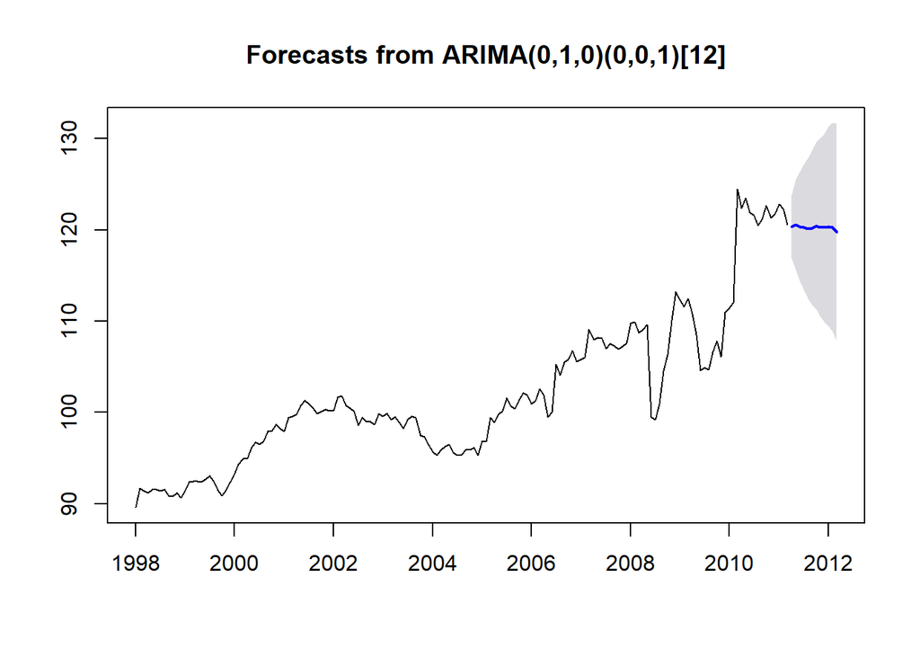

```r
plot(forecastnew12)
```